# The use of topic modeling (STM) in web archives

The following R Notebook shows an experimental analysis of a web archive. The main goal is to identify and analyse dominant topics from websites of five german parties about the election campaign for the european parliament election 2019. For this, a text corpus was constructed, based on a new text extractor tool which was developed by Gassner (2019). The analysis and text extractor is part of the DFG project [‘Web archives – Methods of Digital Humanities in application for creating and accessing web archives’](https://www.dfg.de/en/dfg_profile/statutory_bodies/general_assembly/index.html).

This algorithm and many other methods of topic modeling are part of the R package STM by [Roberts et al. (2018)](https://cran.r-project.org/web/packages/stm/vignettes/stmVignette.pdf). Beside different NLP techniques this package is the main part of this notebook.

```r
#path to the project
knitr::opts_knit$set(root.dir = normalizePath("/home/eckl/analyse_eu_wahl_stm/"))
```

# Data preparation

## Load packages and read json data

```r
library(jsonlite)
library(dplyr)
library(markdown)
library(knitr)
library(kableExtra)
library(ggplot2)
library(tidyr)
library(magrittr)
library(quanteda)
library(spacyr)
library(stm)
library(DT)
library(sna)
library(ggrepel)
#load and convert json to dataframe
json = jsonlite::stream_in(file("data/unique_texts_20191125T124656.json"))
df = jsonlite::flatten(json)

#change the datatype
df$data.released_at.value <- as.Date(df$data.released_at.value)

#delate all duplicate documents & select special columns
df2 <- df %>%
  distinct(data.body.value, .keep_all = TRUE) %>%
  filter(data.body.size > 250) %>%
  filter(data.released_at.value >= "2019-01-01" & data.released_at.value <= "2019-08-01") %>%
  select(meta.name, meta.issuer,meta.type,meta.created_at,
         data.released_at.value, meta.target.netloc,
         data.title.value, data.body.value)
```

## Overview dataframe

| meta.name | meta.issuer | meta.type | meta.created_at | data.released_at.value | meta.target.netloc | data.title.value | data.body.value | data.released_at.y_m | week | month |
| --- | --- | --- | --- | --- | --- | --- | --- | --- | --- | --- |
| SPD, Mitteilung | political_party | article | 2019-11-22T10:54:40.563Z | 2019-03-26 | www.spd.de | Arbeitsgemeinschaft für Bildung (AfB): Mehr Bildung wagen – gute Bildung bedeutet auch gute Inklusion! | Am 26. März 2009 trat die Konvention über die Rechte von Menschen mit Behinderungen in der Bundesrepublik Deutschland in Kraft. Anlässlich des zehnjährigen Jubiläums erklärt der Vorsitzender der Arbei… | 2019-03 | 2019-03-24 | 2019-03-01 |
| Gruene (old design), Thema | political_party | page | 2019-11-22T10:41:28.824Z | 2019-01-24 | www.gruene.de | Sauber Autofahren ab 2030 | Kaum ein Geräusch. Der neue Wagen gleitet nahezu lautlos die Bahnhofstraße entlang. Obwohl vorne und hinten noch viele andere Autos fahren, sind die Rufe der Jungs vom Fußballplatz deutlich zu hören. … | 2019-01 | 2019-01-20 | 2019-01-01 |
| SPD, Mitteilung | political_party | article | 2019-11-22T10:45:16.346Z | 2019-03-30 | www.spd.de | Lars Klingbeil gratuliert Boris Velter zur Wiederwahl als Vorsitzender der Arbeitsgemeinschaft der Sozialdemokratinnen und Sozialdemokraten im Gesundheitswesen (ASG) | Auf der Bundeskonferenz der ASG – Arbeitsgemeinschaft der Sozialdemokratinnen und Sozialdemokraten im Gesundheitswesen – wurde Boris Velter erneut zum Bundesvorsitzenden gewählt. Er tritt damit seine … | 2019-03 | 2019-03-24 | 2019-03-01 |
| SPD, Artikel | political_party | article | 2019-11-22T10:45:26.726Z | 2019-03-23 | www.spd.de | SPD-Europaprogramm beschlossen Kommt zusammen für ein starkes Europa! | Mit einer klar proeuropäischen Haltung will die SPD der europäischen Idee neuen Schub geben. Auf ihrem Parteikonvent für die Europawahl beschloss sie einstimmig ein fortschrittliches Programm, das auf… | 2019-03 | 2019-03-17 | 2019-03-01 |
| CDU, Mitteilung | political_party | article | 2019-11-23T13:58:33.339Z | 2019-03-19 | www.cdu.de | Angela Merkel: Gemeinsam Verantwortung übernehmen | Auf dem Global Solutions Summit in Berlin forderte Angela Merkel eine stärkere internationale Zusammenarbeit zu den zentralen Herausforderungen unserer Zeit – von Globalisierung in der Wirtschaft über… | 2019-03 | 2019-03-17 | 2019-03-01 |

## Summary parties

Number of documents differentiated according to the websites of the parties.

```r
#summary of documents differenced by parties
summary(as.factor(df2$meta.target.netloc))
```

```
   www.afd.de    www.cdu.de    www.csu.de www.gruene.de    www.spd.de
          165            96           181            93           100
```

## Plots

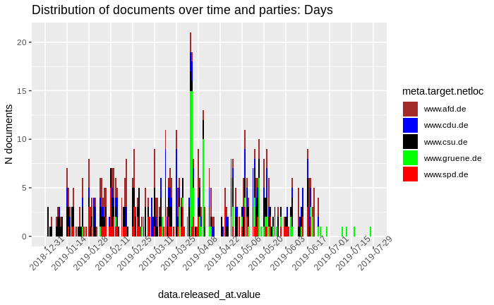

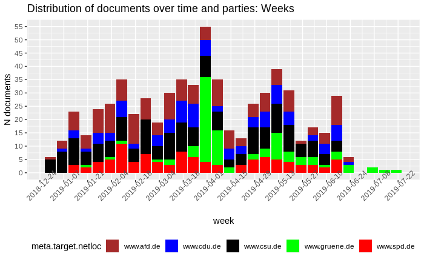

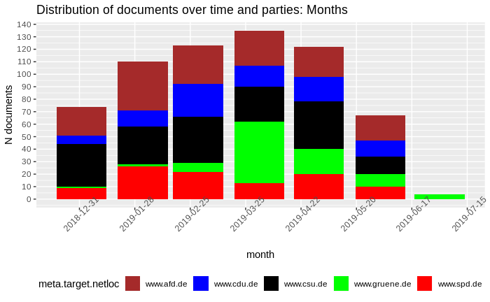

# NLP

## POS-Tagging & Lemmatising & Stop-Words

In the following, [spacy](https://spacy.io/) and the R package [quanteda](https://quanteda.io/) are used.

```r
#Initialize spaCy to call from R.
spacy_initialize(model = 'de' ,refresh_settings = TRUE)
#tokenize and tag the texts, and returns a data.table of the results
parsed <- spacy_parse(df2$data.body.value)
#terminates the python process in the backround
spacy_finalize()

#create tokens and use lammatastion of the words
#remove puncation, numbers, stopwords and special topkens
#min. character are 4
tokens <- as.tokens(parsed, use_lemma = TRUE) %>%
  tokens(remove_punct = TRUE, remove_numbers = TRUE) %>%
  tokens_tolower() %>%
  tokens_remove(c(stopwords('de'), "vgl", "hinsichtlich",
                  "11nd", "z._b.", "cine", "hierzu", "erstens", "zweitens", "deutlich", "tion",
                   "geben", "mehr", "immer", "schon", "gehen", "sowie", "erst", "mehr", "etwa",
                  "dabei", "dis-", "beziehungsweise", "seit", "drei", "insbesondere",
                  stopwords("en")),
                min_nchar = 2L,  padding = TRUE)

#quanteda- Identify and score multi-word expressions, or adjacent fixed-length collocations, from text
#min count 30
collocation <- textstat_collocations(tokens, min_count = 10)
#quanteda - cearce Bi-grams
tokens <- tokens_compound(tokens, collocation, join = FALSE)

#quanteda - Get or set variables associated with a document in a corpus, tokens or dfm object.
docvars(tokens) <- df2 %>% select(data.body.value, data.released_at.value, meta.target.netloc)


dfm_parties <- tokens %>%
  dfm() %>%
  dfm_select(min_nchar = 2L) %>%
  dfm_trim(min_docfreq = 5) %>%  # minimum 50 documents (removes rare terms)
   dfm_trim(max_docfreq = 0.5,
            docfreq_type = 'prop') # maximum in 25 percent of documents (stop words)


save.image('output_data/web_archive_eu_election_tokens.RData')

length(parsed$token)
```

The corpus includes 297.742 tokens form 635 documents.

# STM - Topic Modeling

## Evaluation

Different evaluation methods are discussed in the literature, whereby the coherence measure of Mimno (2011) is often used to determine the number of topics. Mimno’s (2011) algorithm emphasizes the number and weighting of co-occurrences of words in the documents for the quality of the topics. Beside Mimno (2011) the exclusivity is an another helpful metric (Bischof & Airoldi 2012) and Rogers et al. (2014) use both metrics to calculate the optimal number of topics. However, it should also be noted here that a particularly high degree of this metrics is not synonymous with a human model that is easy to interpret. Therefore, it is essential to calculate and compare different models, as well as to examine the documents themselves qualitatively on a random basis. ### Overview

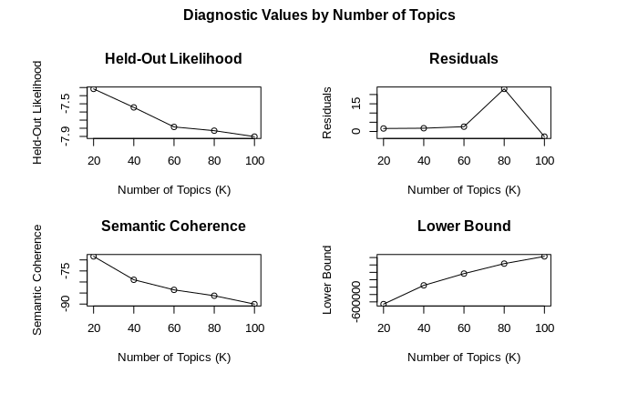

### Semantic Coherence & Exclusivity

After comparing several models and evaluating the topics’ ability to be interpreted, the model with 60 topics was selected.

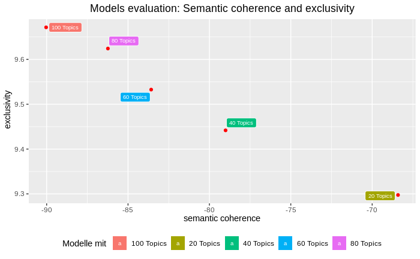

## Calculate the “best” model

## Overview topics

For a better human interpretation of the topics, the STM Package offers the possibility to create differently weighted word lists of the individual topics (Roberts et al. 2018). The respective weights emphasize different characteristics of the words in context of the documents and thus can be facilitate the human process of labelling of the topics. Two weights were used for this study.

### Highest probability wight

| X1 | X2 | X3 | X4 | X5 | X6 | X7 | X8 | X9 | X10 | X11 | X12 | X13 | X14 | X15 | X16 | X17 | X18 | X19 | X20 | X21 | X22 | X23 | X24 | X25 | X26 | X27 | X28 | X29 | X30 | … |
| --- | --- | --- | --- | --- | --- | --- | --- | --- | --- | --- | --- | --- | --- | --- | --- | --- | --- | --- | --- | --- | --- | --- | --- | --- | --- | --- | --- | --- | --- | --- |
| platzen | tempo | geschäftsführerin | zuständigkeit | csu | verlässlich | wissenschaftliche | füracker | pflege | forschung | klären | de | grundsatzprogramm | iran | ziemiak | negativ | sozialstaat | entfalten | leitfragen | orbán | uhr | artenschutz | weber | afd | erfinden | ungarn | wilhelmstraße_berlin | übrig | grundrente | innere | … |
| werkstattgespräch | kohleausstieg | rechtsextrem | gottschalk | söder | europa | wissenschaft | grundsteuer | pflegebedürftige | gleichwertig | neu_grundsatzprogramm | la | tauschen | ausschluss | äußer | kirche | arbeitslosengeld | china | workshopergebnisse | kommt_zusammen | katarina_barley | million_euro | vorgang | hinweis | global | wiederaufbau | auftaktbilder | parlamentarisch | widersprechen | herrmann | … |
| praktiker | klimaschutz | mdl | bündnis_90/die | blume | csu | wissenschaftlich | bundesverfassungsgericht | sozialstaat | bildung | zwischenbericht | que | grün | international | annegret_kramp-karrenbauer | innenminister | bürgergeld | abkomme | hinterher | sozial_europa | finden_statt | bayer | afd | verfassungsschutz | gentechnik | mitgliedstaaten | willy-brandt-haus_wilhelmstraße | bündnis_90/die | spd | bayerische_polizei | … |
| integration | klimaziele | mdb | kay | volkspartei | manfred_weber | parteivorstand | bundesfinanzminister | grundkonsens | einheit | uhr | en | michael_kellnern | einstellen | cdu | walter_lübcke | sanktion | markt | maschine | hetzer | frage_stehen | landwirtschaft | türkei | gutachten | pflanze | regierung | afp_ap | 90/die_grünen | barley | grenzkontrollen | … |
| migrations- | kommission | rechtsextremismus | facebook | positionieren | europawahl | verhältnis | unbürokratisch | nahles | cdu-geführte_bundesregierung | züchtung | le | facebook | heiko | csu | widerwärtig | neuanfang | amerikanisch | startkonvent | mitbestimmung | uhr_einlass | freistaat | eu | dr._alexander | züchtung | raten | bilden_poolführer | datum | konservative | polizist | … |
| flüchtlingspolitik | erneuerbare_energie | bundesfachausschuss | sprecher | afd | annegret_kramp-karrenbauer | grün | wohnen | pflegekräfte | mauern | juni | con | wählen | nahe | cdu-vorsitzende_annegret | ezb | nahles | usa | weltregionen | europa | bitten_melden | nahrung | jörg_meuthen | bundessprecher | lebensgrundlagen | mittelmeer | bundespressekonferenz_bitten | gesetzlich | steuererhöhungen | rund | … |
| cdu | ausstieg | e.v. | finanzpolitische | weber | eu | fraktion | scholz | gut_löhne | bund | 19:00 | il | via | region | cdu_deutschland | alice_weidel | spd | japan | anfang | mindestlohn | 12:00_uhr | bayerische_staatsregierung | vaterländer | alexander_gauland | wandeln | eu | dpa_afp | betrieb | katarina_barley | laut_herrmann | … |
| migration | betreiber | sitzung | folgende | erneuerung | gemeinsames_wahlprogramm | faktum | finanzminister | aktion | schön | bundesvorstand | el | grünen | militärisch | altmaier | deutsch_stadt | andrea_nahles | vertragen | kapitalismus | weber | lars_klingbeil | reichhart | europa | medium | natur | korruption | fotograf | abgeordnete | bedürftigkeitsprüfung | feuerwehr | … |
| flüchtling | verkehrswende | präsidium | grundsteuer | markus_söder | stark_europa | historische | urteilen | bezahlung | karliczek | grundsatzprogramm | un | robert_habeck | maas | sozial_marktwirtschaft | mord | grundsicherung | globalisierung | autoritär | timmermans | pressestelle(at)spd.de | volksbegehren | wähler | haldenwang | agenda | europäisch | fotograf_zugelassen | jens_spahn | udo_bullmann | erklären_herrmann | … |
| professor_dr. | auto | feminismus | erhebung | nürnberg | soziale_sicherheit | partei | reform | altenpflege | digitalpakt | mandat | nous | pdf | dialog | europawahl | bundesvorstandsmitglied | arbeitslos | start-ups | ökologisch | spd-spitzenkandidatin | 2019,um | kommune | evp-spitzenkandidat | dr._jörg | verfahren | flüchtling | freie_fotograf | fraktion | nahles | million_euro | … |

### Frex - exclusivity wight

| X1 | X2 | X3 | X4 | X5 | X6 | X7 | X8 | X9 | X10 | X11 | X12 | X13 | X14 | X15 | X16 | X17 | X18 | X19 | X20 | X21 | X22 | X23 | X24 | X25 | X26 | X27 | X28 | X29 | X30 | … |
| --- | --- | --- | --- | --- | --- | --- | --- | --- | --- | --- | --- | --- | --- | --- | --- | --- | --- | --- | --- | --- | --- | --- | --- | --- | --- | --- | --- | --- | --- | --- |
| platzen | tempo | rechtsextrem | zuständigkeit | csu | verlässlich | wissenschaft | füracker | pflege | forschung | neu_grundsatzprogramm | que | michael_kellnern | iran | ziemiak | negativ | arbeitslosengeld | markt | leitfragen | kommt_zusammen | lars_klingbeil | artenschutz | weber | verfassungsschutz | global | regierung | wilhelmstraße_berlin | parlamentarisch | barley | herrmann | … |
| werkstattgespräch | kohleausstieg | e.v. | gottschalk | volkspartei | europa | wissenschaftliche | grundsteuer | pflegebedürftige | bildung | klären | il | grundsatzprogramm | international | annegret_kramp-karrenbauer | kirche | sozialstaat | china | anfang | orbán | uhr_einlass | landwirtschaft | türkei | gutachten | wandeln | raten | willy-brandt-haus_wilhelmstraße | übrig | grundrente | innere | … |
| integration | klimaziele | präsidium | sprecher | blume | gemeinsames_wahlprogramm | wissenschaftlich | bundesfinanzminister | nahles | einheit | bundesvorstand | le | facebook | ausschluss | sozial_marktwirtschaft | innenminister | sanktion | standard | weltregionen | sozial_europa | finden_statt | million_euro | wähler | alexander_gauland | agenda | ungarn | auftaktbilder | 90/die_grünen | konservative | grenzkontrollen | … |
| praktiker | kommission | mdb | kay | erneuerung | stark_europa | verhältnis | scholz | bezahlung | gleichwertig | zwischenbericht | con | wählen | region | cdu-vorsitzende_annegret | geist | bürgergeld | abkomme | workshopergebnisse | mitbestimmung | katarina_barley | landwirt | jörg_meuthen | dr._alexander | erfinden | mitgliedstaaten | atrium_willy-brandt-haus | gesetzlich | steuererhöhungen | bayerische_polizei | … |
| migration | klimaschutz | rechtsextremismus | facebook | söder | manfred_weber | parteivorstand | reform | gut_löhne | mauern | juni | el | grün | militärisch | cdu_deutschland | alice_weidel | nahles | usa | autoritär | hetzer | 2019,um | volksbegehren | vaterländer | bundessprecher | gentechnik | mittelmeer | afp_ap | datum | bedürftigkeitsprüfung | laut_herrmann | … |
| migrations- | erneuerbare_energie | bundesfachausschuss | bündnis_90/die | markus_söder | annegret_kramp-karrenbauer | fraktion | bundesverfassungsgericht | sozialstaat | cdu-geführte_bundesregierung | züchtung | nous | via | einstellen | wohlstand | mord | grundsicherung | globalisierung | maschine | mindestlohn | 12:00_uhr | bayerische_staatsregierung | vorgang | medium | verfahren | europaparlament | bilden_poolführer | bündnis_90/die | spd | rund | … |
| migrationspolitik | verkehrswende | geschäftsführerin | finanzpolitische | nürnberg | soziale_sicherheit | partei | wohnen | pflegekräfte | bund | mandat | de_la | pdf | nahe | äußer | bundesvorstandsmitglied | hartz_iv | vertragen | startkonvent | gleich | europawahl_katarina | freistaat | juncker | haldenwang | lebensgrundlagen | flüchtling | bundespressekonferenz_bitten | fraktion | rechtspopulisten | polizist | … |
| flüchtling | ausstieg | mdl | entlastung | markus_blume | evp-spitzenkandidat | historische | unbürokratisch | aktion | schön | diskutieren | nos | robert_habeck | kommission | paul_ziemiak | ezb | einfahren | amerikanisch | kapitalismus | timmermans | veranstaltung | kommune | evp-spitzenkandidat | afd | pflanze | korruption | dpa_afp | pflicht | widersprechen | feuerwehr | … |
| zwei | einleiten | sitzen | afd-fraktion | seehofer | europawahl | grün | koalition | angehörige | land | antwort | się | grünen | dialog | altmaier | aufnahme | qualifizierung | global | macht | spd-spitzenkandidatin | 11:00_uhr | reichhart | eu | hinweis | natur | pol | fotograf | betrieb | udo_bullmann | erklären_herrmann | … |
| flüchtlingspolitik | dafür_müssen | sitzung | information | parteivorsitzenden | csu | faktum | finanzminister | arbeitsbedingungen | innovation | partei | want | april | osten | cdu | migration | arbeitslos | japan | zusammenleben | sozialdemokrat | uhr | angebot | afd | fragwürdig | veränderung | humanitär | fotograf_zugelassen | abgeordnete | katarina_barley | bayern_innenminister | … |

## Topic labels

```r
#Topics with the label "xxx_" mean that the topic cannot be interpreted well.
topic.id <- c(seq(1,60,1))
topic.label <- c("Flüchtlingespolitik", "Kohleausstieg", "Rechtsextremismus & Bundestag", "xxx_Gottschalk",
                 "Söder & CSU", "CSU & Europawahl", "xxx_grüne", "Grundsteuer", "Pflege", "Forschung & Bildung",
                 "xxx_programm", "xxx_de", "Grundsatzprogramm der Grünen", "Iran & Außenpolitik",
                 "CDU & Europawahl", "Casa Walter Lübcke", "SPD Harz kritik & Reform", "Handelsabkommen",
                 "xxx_workshop", "Orban, Weber, Timmerman", "xxx_presse", "Artenschutz & Bayern",
                 "Weber & afd & Türkei", "afd &  Verfassungsschutz", "Natur", "Regierungen und EU",
                 "xxx_parteizentralen", "xxx_parlamentarisch", "Grundrente & Konflikt",
                 "Bayern & Grenzkontrolle", "Gründe für Grundrente", "DDR & Mauerfall", "Lübcke & Hass",
                 "Eurozone & Ökologie & Ökonomie", "xxx_spende", "Baukindergeld & Wohnungen",
                 "xxx_generell", "Investitionen Infrastruktur & scharze Null",
                 "Antisemitismus & musl. Zuwanderung", "Söder & Weber vs. Populisten",
                 "Habeck & Garantiesicherung (Diesel)", "Bayern Staatsregierung", "EU & soziale Ungleichheit",
                 "Krisen EU", "Landwirtschaft & Pestizide", "Starke-Familien-Gesetz",
                 "Weber & EVP Spitzenkandidat", "Bundeswehr & Söder", "Urheberrecht", "xxx_cdu",
                 "xxx_schwangere", "Fahrverbote in Städten", "Klimaschutz Bewegung (FFF)",
                 "Demokratie & Rechtsstaatlichkeit", "Polizei & Sicherheit", "twitter & Gleichstellung",
                 "Großbritanien & Demokratie", "Kriminalität & Ursachen", "xxx_aufmerksam",
                 "Grüne & Programmatik")

df.topic.labels <- as.data.frame(topic.id)
df.topic.labels$label <- topic.label

# "bad" topics delate
topic.del <- c(4, 7, 11, 12, 19, 21, 25, 27, 28, 35, 37, 50, 51, 59)
```

## Visualisation

### Most discucssed topics

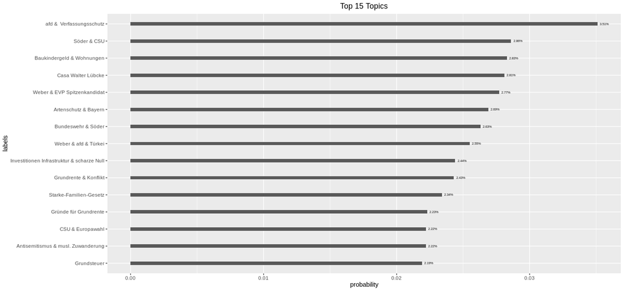

### Word clouds

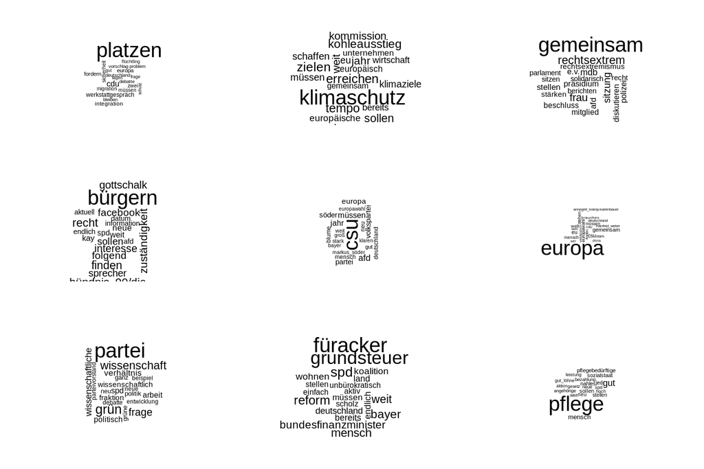

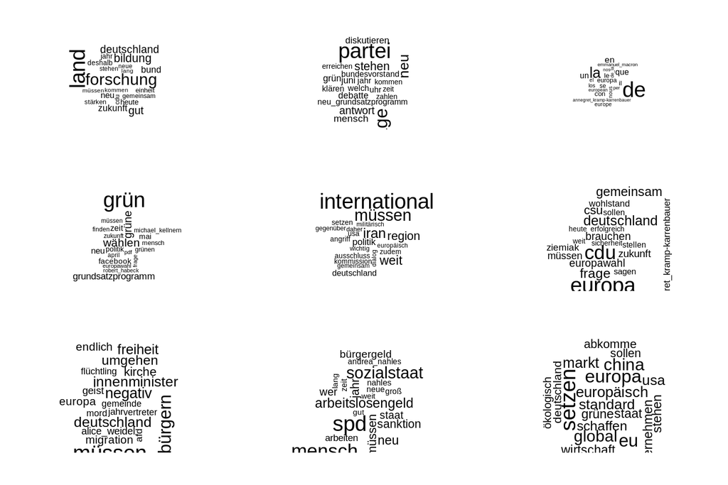

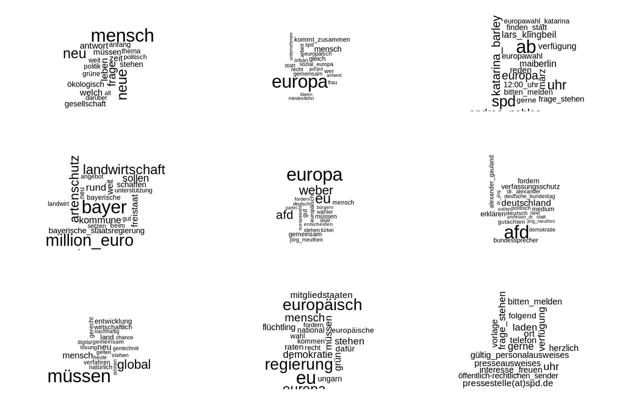

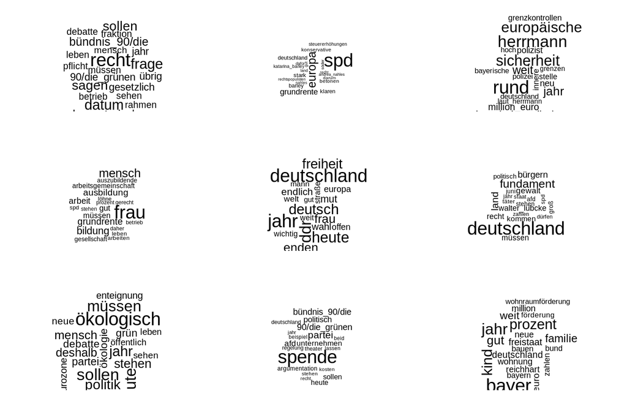

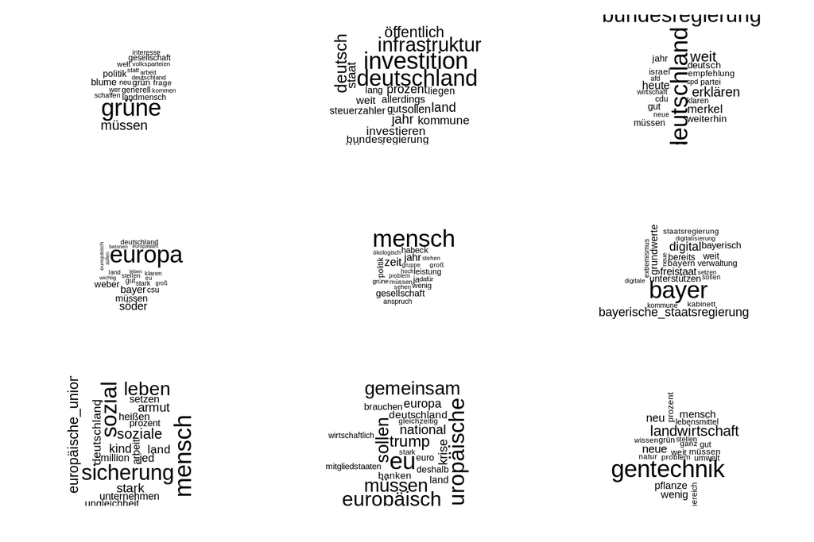

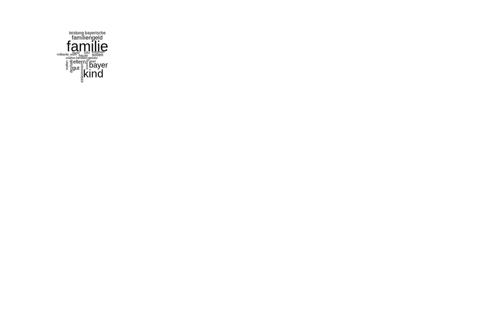

```r
library(RColorBrewer)
library(wordcloud)
#topic.count <- 140
par(mfrow=c(3,3))
for (i in seq_along(sample(df.s2$id)))
{
  cloud(model.stm, topic = i, scale = c(4,.40),
        max.words = 20, main = paste0("Topic "))
}
```

### Word-Topic comparison

This plot calculates the difference in probability of a word for the two topics, normalized by the maximumdifference in probability of any word between the two topics.

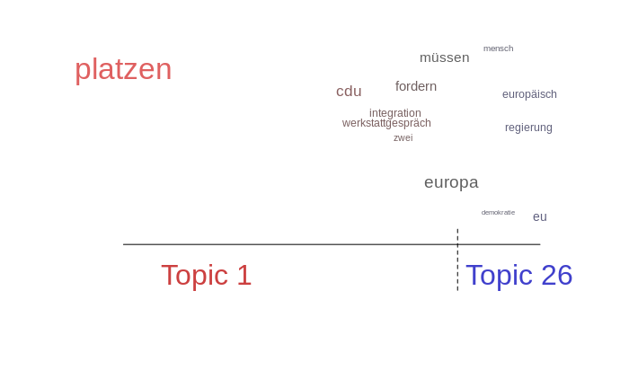

```r
plot(model.stm, type = "perspectives", topics = c(1,26), n = 15)
```

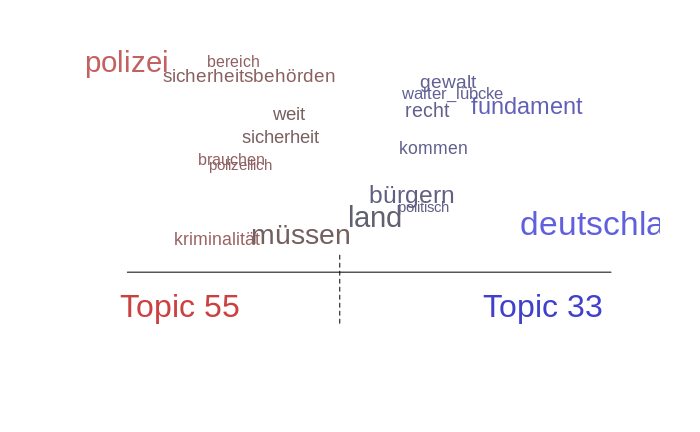

```r
plot(model.stm, type = "perspectives", topics = c(55,33), n = 20)
```

### Correlation grpah

For a better interpretation of the model and for a better understanding of the topics and how they relate to each other, the STM Package provides the calculation of a correlation graph. In this context, correlation means the probability that two topics within a document will co-occur together. The nodes of this network represent the individual topics and a connection between two nodes means a positive correlation that exceeds a threshold previously defined by humans. The larger the nodes of the network (or their labels), the more frequently the topic appears in the corpus. The thicker the edges and the closer together the topics are visualized, the greater the probability that two topics correlate.

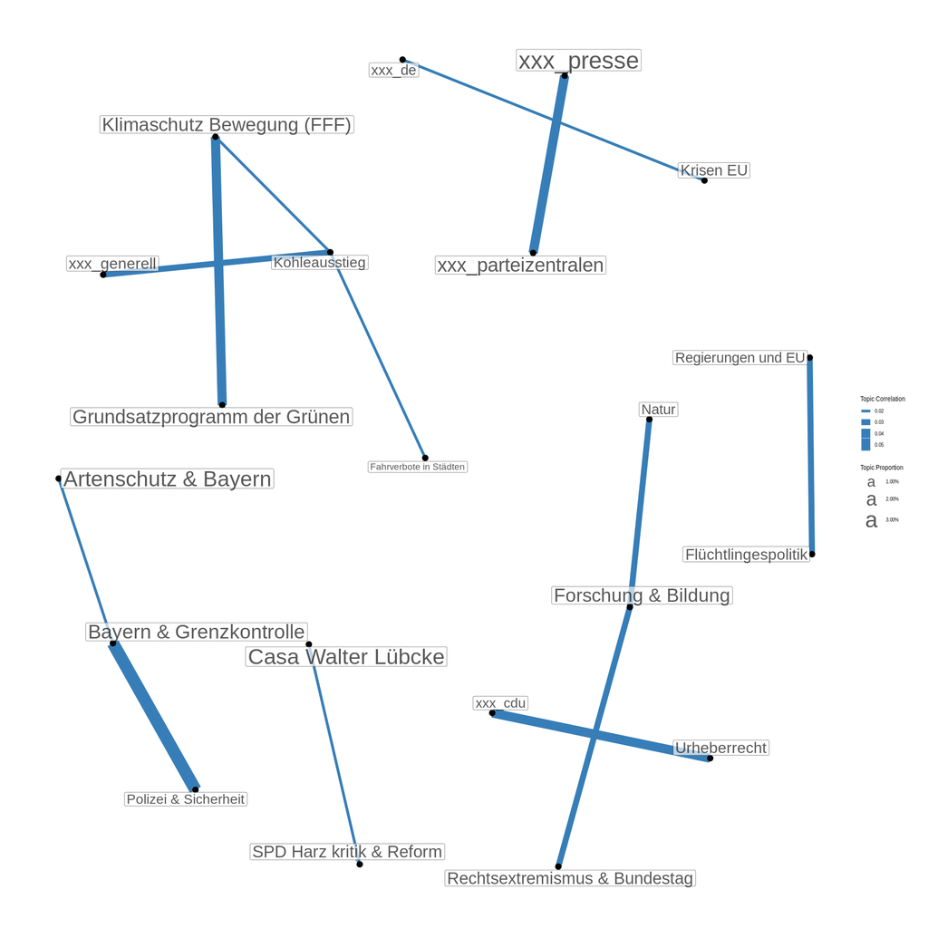

```r
library(stminsights)
library(shiny)
library(shinydashboard)
library(ggraph)
stm_corrs <- get_network(model = model.stm,
                         method = 'simple',
                         labels = paste(df.topic.labels$label),
                         cutoff = 0.02,
                         cutiso = TRUE)
graph <-ggraph(stm_corrs, layout = 'fr') +
  geom_edge_link(
    aes(edge_width = weight),
    label_colour = '#fc8d62',
    edge_colour = '#377eb8') +
  geom_node_point(size = 4, colour = 'black')  +
  geom_node_label(
    aes(label = name, size = props),
    colour = 'black',  repel = TRUE, alpha = 0.65) +
  scale_size(range = c(5, 13), labels = scales::percent) +
  labs(size = 'Topic Proportion',  edge_width = 'Topic Correlation') +
  scale_edge_width(range = c(2, 9)) +
  theme_graph()
graph
```

### Clustering Modularity

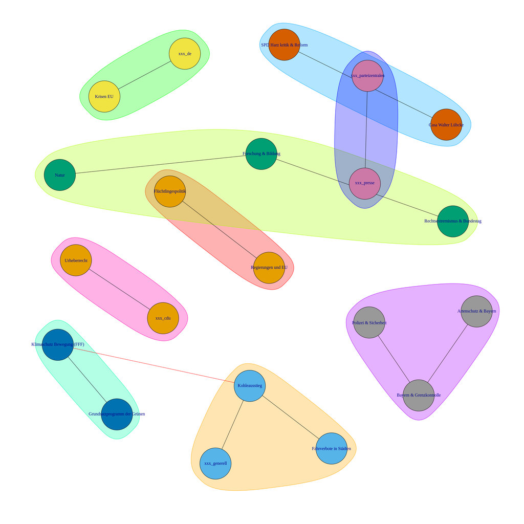

```r
library(igraph)
clp <- cluster_label_prop(stm_corrs)
plot_clp <- plot(clp, stm_corrs)
```

# Regression I

The innovative feature of the STM Package is the possibility to integrate covariates into the LDA model (Roberts et al. 2018). This means that the topical prevalence is set concerning other characteristics. The use of possible covariates should be justified theoretically, as it is crucial why the chosen characteristic can influence the frequency with which a topic is discussed. To be able to analyze the occurrence of topics over time, the publication day of the text on the webside is used. A regression is calculated in which the dependent variable is the probability of a topic occurring in a documentand and the independent variable is the publication day of the text on the webside (Roberts et al. 2014). ## Calcualte Estimate Effect

## Ugly plots

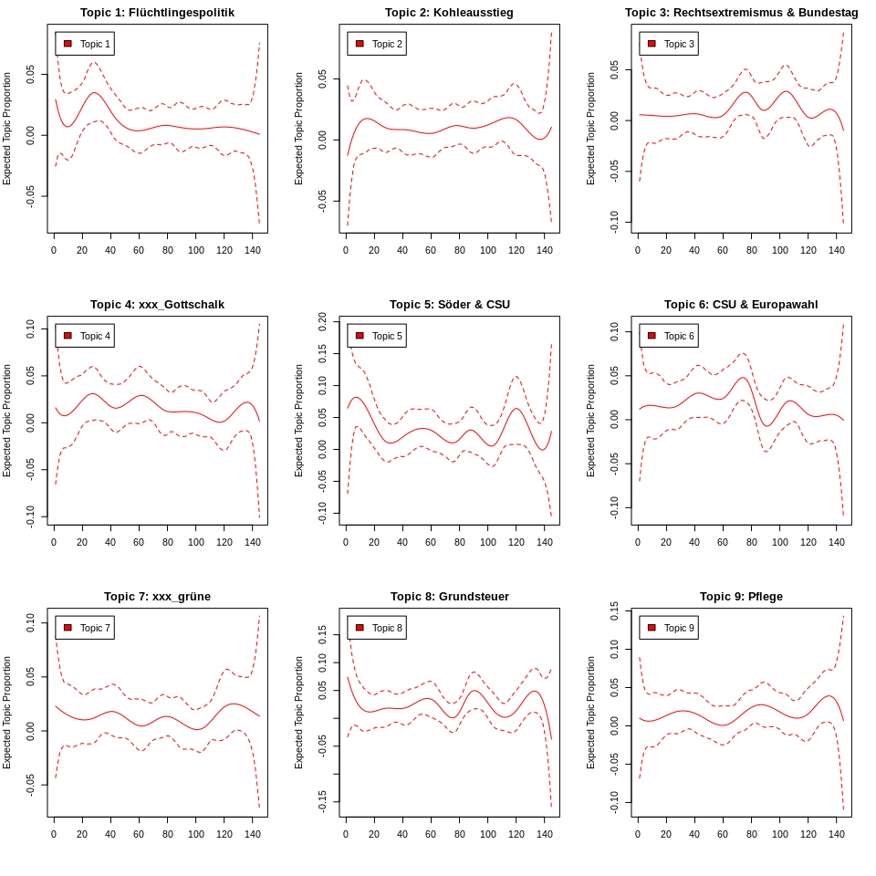

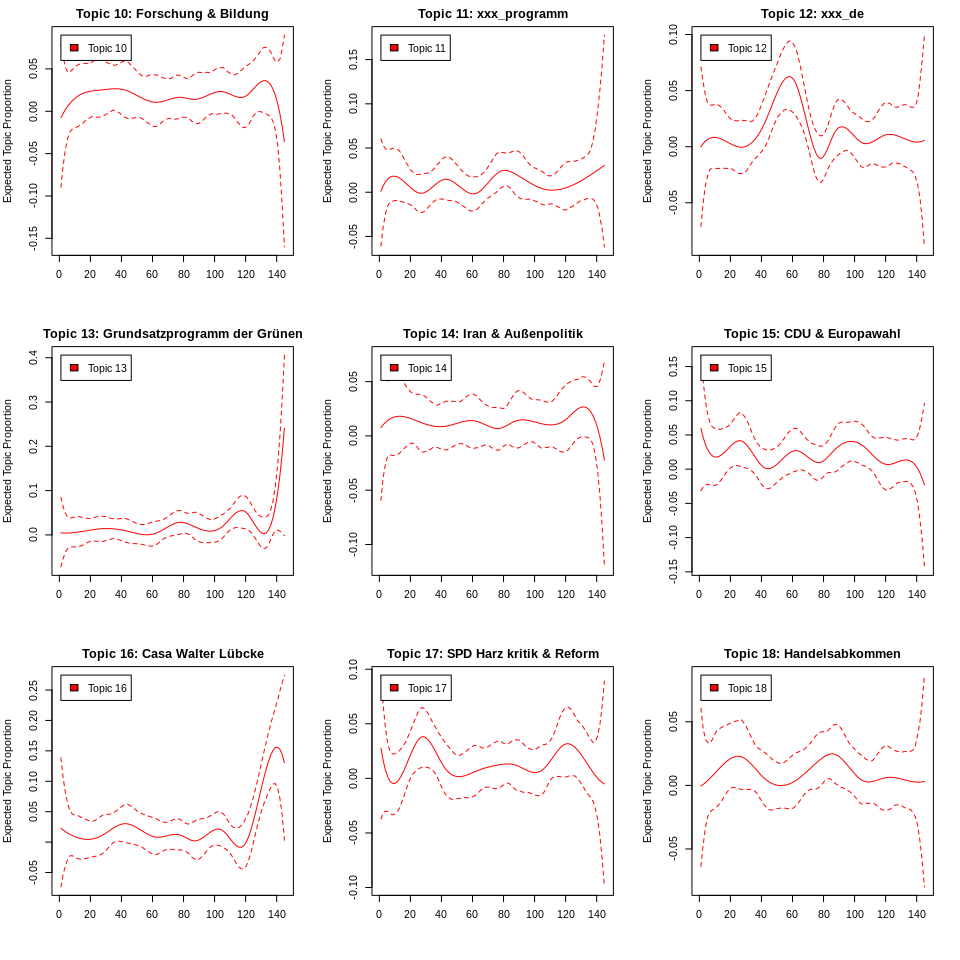

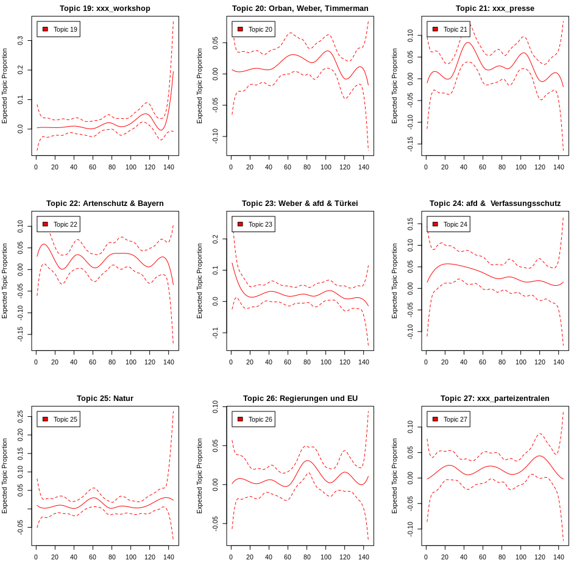

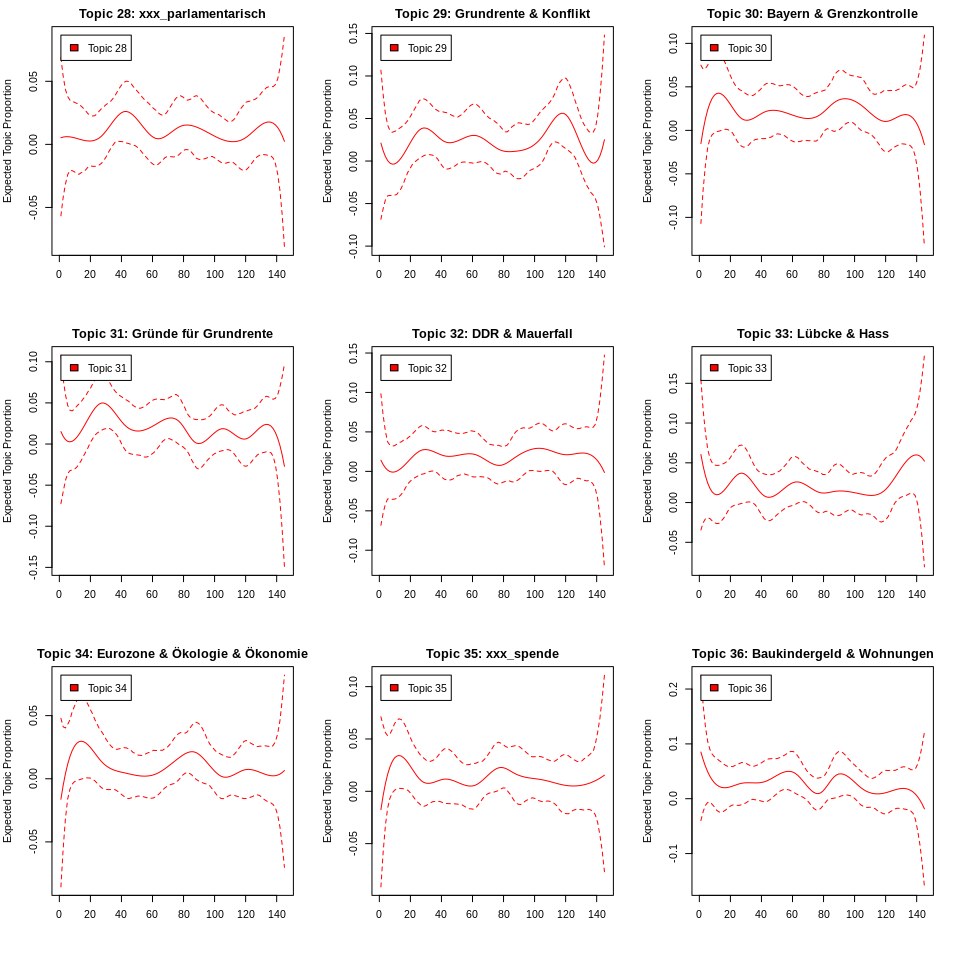

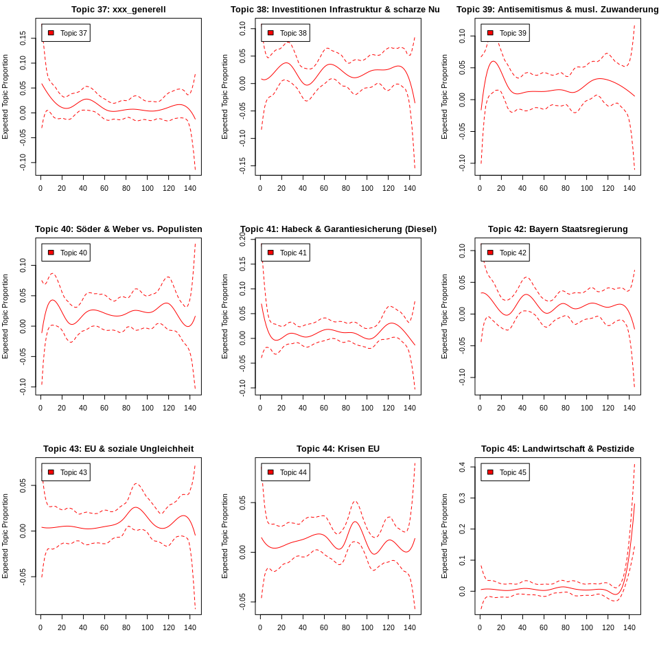

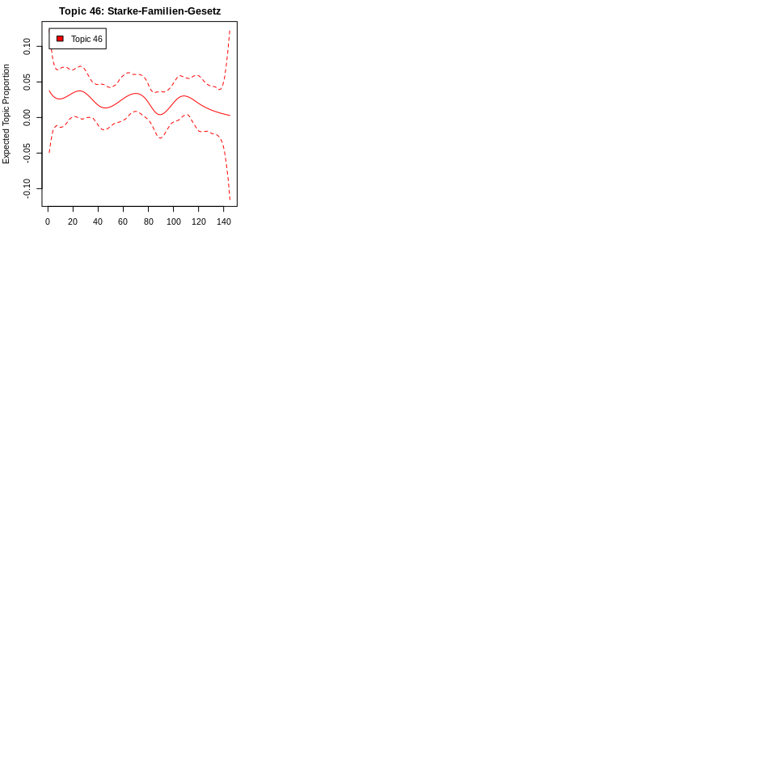

```r
par(mfrow=c(3,3))
for (i in seq_along(df.s2$id))#df.s %>% filter(id
{
  plot(model.stm.ee, "datum", method = "continuous", topics = i, main = paste0("Topic ",                              df.topic.labels$topic.id[i], ": ", df.topic.labels$label[i]))
}
```

## Pretty plot

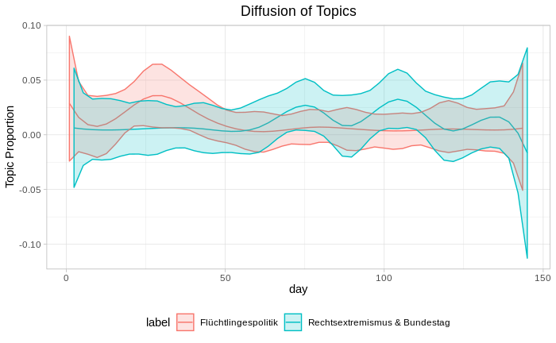

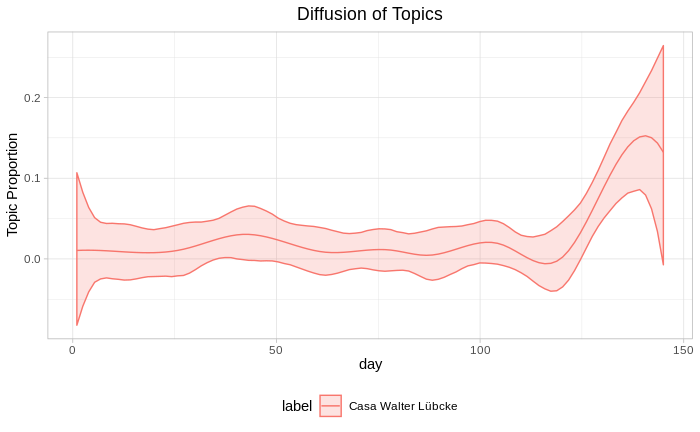

## Regression II

Dependent variable: the probability of a topic occurring in a document Independent variable: Webside of the parties Here you can see which party treats the issue more or less in relation to the other parties.

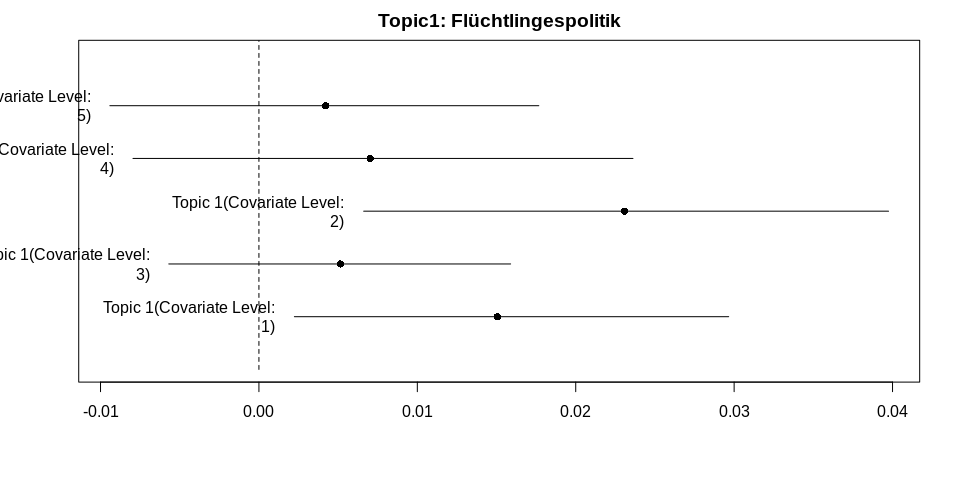